# coal_analysis

Let’s get mining!

(Fair warning though: the analysis here will be brief in lieu of a public-facing application of the models’ results)

Let’s just look at the “top 15” in table form for now in a few categories. We’ll look at companies, states, injured body parts, and injury sources.

| OPERATOR_NAME | Freq |
| --- | --- |
| Consolidation Coal Company | 3149 |
| Jim Walter Resources Inc | 2257 |
| The American Coal Company | 2053 |
| Peabody Midwest Mining, LLC | 2000 |
| Newmont USA Limited | 1944 |
| Freeport-McMoRan Morenci Inc. | 1760 |
| Vulcan Construction Materials, LLC | 1744 |
| Buzzi Unicem USA | 1543 |
| Stillwater Mining Company | 1535 |
| Eastern Associated Coal LLC | 1485 |
| Drummond Company Inc | 1383 |
| Rosebud Mining Company | 1343 |
| Consol Pennsylvania Coal Company | 1195 |
| Consol Pennsylvania Coal Company LLC | 1177 |
| Emerald Coal Resources LP | 1152 |

| state | Freq |
| --- | --- |
| WV | 36017 |
| KY | 26363 |
| PA | 17395 |
| IL | 10848 |
| TX | 9832 |
| VA | 8870 |
| AL | 8235 |
| AZ | 7501 |
| NV | 7403 |
| IN | 7347 |
| CA | 7123 |
| OH | 6219 |
| WY | 6107 |
| CO | 5157 |
| MO | 5018 |

| INJ_BODY_PART | Freq |
| --- | --- |
| FINGER(S)/THUMB | 33167 |
| NO VALUE FOUND | 29220 |
| BACK (MUSCLES/SPINE/S-CORD/TAILBONE) | 28065 |
| KNEE/PATELLA | 15691 |
| SHOULDERS (COLLARBONE/CLAVICLE/SCAPULA) | 11927 |
| MULTIPLE PARTS (MORE THAN ONE MAJOR) | 11529 |
| HAND (NOT WRIST OR FINGERS) | 10552 |
| EYE(S) OPTIC NERVE/VISON | 10515 |
| ANKLE | 8139 |
| WRIST | 6463 |
| FOOT(NOT ANKLE/TOE)/TARSUS/METATARSUS | 5686 |
| CHEST (RIBS/BREAST BONE/CHEST ORGNS) | 5548 |
| HIPS (PELVIS/ORGANS/KIDNEYS/BUTTOCKS) | 5149 |
| HEAD,NEC | 4502 |
| NECK | 4019 |

| INJURY_SOURCE | Freq |
| --- | --- |
| NO VALUE FOUND | 28992 |
| METAL,NEC(PIPE,WIRE,NAIL) | 24591 |
| GROUND | 14806 |
| METAL COVERS & GUARDS | 13662 |
| BROKEN ROCK,COAL,ORE,WSTE | 10943 |
| CAVING ROCK,COAL,ORE,WSTE | 9785 |
| MINE FLOOR,BOTTOM,FOOTWAL | 7567 |
| MISCELLANEOUS,NEC | 6764 |
| SURFACE MINING MACHINES | 6463 |
| PULVERIZED MINERAL (DUST) | 5486 |
| KNIFE | 4875 |
| BELT CONVEYORS | 4680 |
| FLOOR,WALKING SURF-NOT UG | 4519 |
| HGHWY ORE CARIER,LRGE TRK | 4188 |
| MINE JEEP,KERSEY,JITNEY | 3789 |

Let’s do the annoying part, then look into exploring all the many stories from the narratives.

We’ll do LDA first, then PCA.

## Latent Dirichlet Allocation

For LDA, I used the `tidylda` package written by an acquaintance and R-Gov presenter [Tommy Jones](https://www.jonesingfordata.com/). This provides hooks to extract useful calculations that are tidyverse-friendly.

```r
# raw coal dataset from MSHA
docs <- read_rds('data/raw_coal_data.rds')

# LDA modeling ---------------------------------------------------------

# tokenize using tidytext's unnest_tokens
tidy_docs <- docs %>%
  mutate(ACC_ID = as.character(ACC_ID)) %>%
  select(ACC_ID, NARRATIVE) %>%
  unnest_tokens(
    output = word,
    input = NARRATIVE,
    stopwords = stop_words$word,
    token = "ngrams",
    n_min = 1, n = 2) %>%
  count(ACC_ID, word) %>%
  filter(n>1)
# Filtering for words/bigrams per document, rather than per corpus


# filter words that are just numbers
tidy_docs <- tidy_docs %>%
  filter(! stringr::str_detect(tidy_docs$word, "^[0-9]+$"))

# append observation level data
colnames(tidy_docs)[1:2] <- c("document", "term")

# turn a tidy tbl into a sparse dgCMatrix
# tidylda has support for several document term matrix formats
d <- tidy_docs %>%
  cast_sparse(document, term, n)

set.seed(123)

lda_model <-
  tidylda(
    data = d,
    k = 10,
    iterations = 200,
    burnin = 175,
    alpha = 0.1,
    eta = 0.05,
    optimize_alpha = FALSE,
    calc_likelihood = TRUE,
    calc_r2 = TRUE,
    return_data = FALSE)

# save model for quick-reading later
# write_rds(lda_model, "data/lda_model.RDS")

# TODO:
# Somehow from the trained model it seems like only training on
# 154949 documents instead of the given 231866 documents

# augment LDA matrix(es) with document IDs (join table: doc, term, topic)
join_table <-
  augment(
    lda_model,
    data = tidy_docs)
```

The above code takes many minutes to run, so I’ve just loaded the pre-trained `lda_model`. Let’s take a look at the included `summary` object.

```r
lda_model$summary
```

```
# A tibble: 10 × 4
   topic prevalence coherence top_terms
   <dbl>      <dbl>     <dbl> <chr>
 1     1       9.3  -0.000642 cable, bar, door, leg, causing, ...
 2     2       9.68 -0.00318  truck, finger, miner, hammer, loader, ...
 3     3       8.88 -0.000661 wrench, fell, ankle, conveyor, rib, ...
 4     4      10.7   0.0187   hand, eye, bolt, left, drill, ...
 5     5       7.98  0.0179   pain, shoulder, scoop, bucket, water, ...
 6     6       9.32  0.00844  rock, belt, finger, hand, top, ...
 7     7       9.01  0.0137   hoist, metal, head, piece, thumb, ...
 8     8      11.6   0.0215   ee, foot, knee, pipe, left, ...
 9     9      11.6   0.00406  employee, arm, factor, injury, motor, ...
10    10      11.9   0.0396   fall, roof, ft, feet, elevator, ...
```

One other thing to mention here, one major product from the processing above is our `join_table` that has three useful columns: `document`, `term`, and `topic`. We can now use this to filter, join, and/or select any of those we want to jump back and forth between them (more on that in the “Explore” tab).

## PCA

For Principle Components Analysis, we have to ‘massage’ the data a bit. We can only use numerical columns, and only non-zero ones at that. Plus, there were some “ID number” columns that made sense to keep and some that made sense to drop. Also, there were a peculiarly and inconveniently non-overlapping set of missing values in some columns that ended up needing to be dropped. About 4 columns, each with about 20% missing, but their missingness conglomerated to cover about 95% of the rows taken as a whole. So I only kept one of those rows since it had a lot of variation and not a lot of missing values.

As a shout-out to Madde Pickens, doing my tutorial as she suggested was actually super-helpful for this process. It would have taken me much, much longer to isolate the ‘missingness trouble’ without having just written a tutorial on 3 packages to assist with that. Thanks!

```r
# docs <- read_rds('data/raw_coal_data.rds')
docs <- coal

drop_cols <-
  c('ACC_ID',
    'DOCUMENT_NO',
    'CLOSED_DOC_NO',
#    'TOT_EXPER',    I kept this column (good variation, but 40k missing)
    'MINE_EXPER',
    'JOB_EXPER',
    'SCHEDULE_CHARGE',
    'DAYS_RESTRICT',
    'DAYS_LOST')


pca_docs <-
  docs %>%
  select(
    where(is.numeric),
    -all_of(drop_cols)) %>%
  drop_na() %>%
  select_if(colSums(.) != 0)


pca_model <-
  pca_docs %>%
  prcomp(scale = TRUE)

joined_pca <-
  pca_model %>%
  augment(pca_docs)
```

So let’s just do some sanity checks to see if our PCA gave any variation, or if everything is still lumped on top of itself.

Let’s plot the points along the first two principle components (PCs), then see if the rotation matrix is sensible, and we’ll wrap up with covering the variance explained visually.

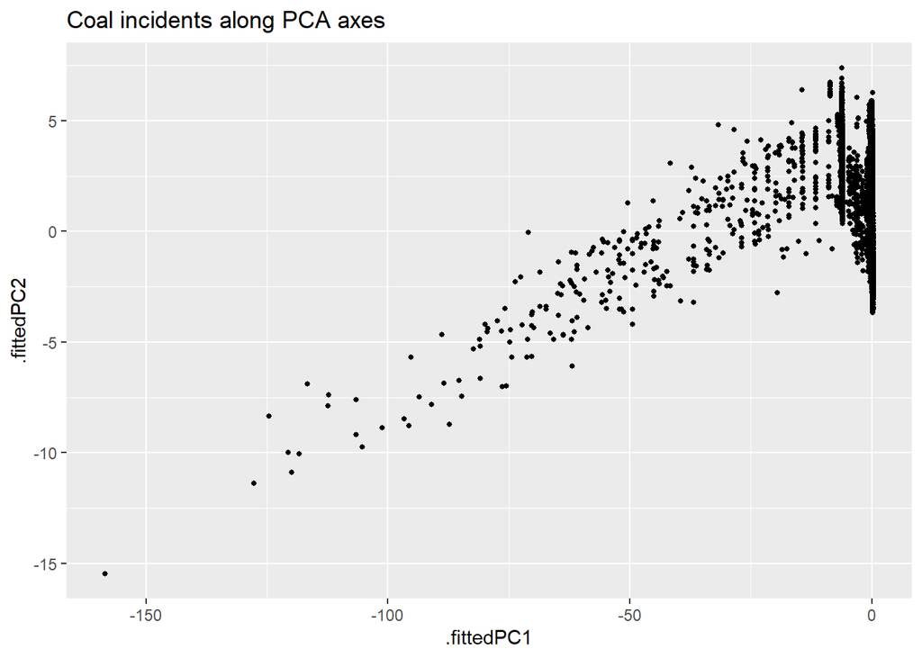

```r
# plot data on PCs

joined_pca %>%
  ggplot(
    aes(
      .fittedPC1,
      .fittedPC2)) +
  geom_point(size = 1.0) +
  labs(title = 'Coal incidents along PCA axes')
```

Okay, that has a big lump in one spot, but has some striations that we can pretend spread the data out well enough. But just for giggles, let’s check another pair of PCs just to see what happens.

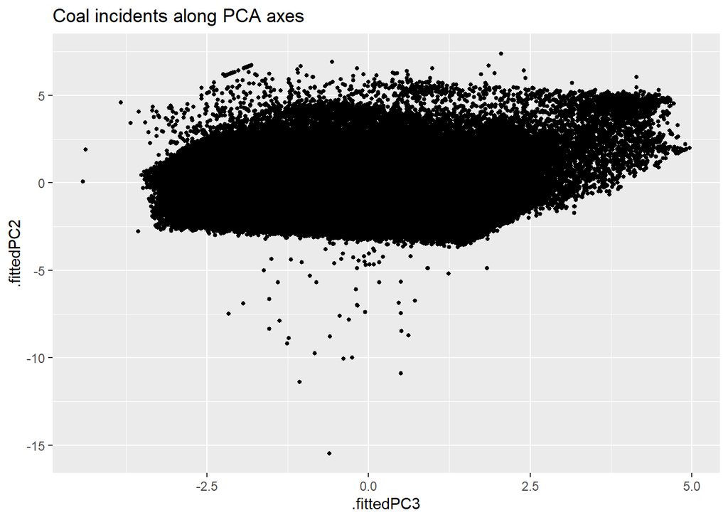

```r
# plot data on PCs

joined_pca %>%
  ggplot(
    aes(
      .fittedPC3,
      .fittedPC2)) +
  geom_point(size = 1.0) +
  labs(title = 'Coal incidents along PCA axes')
```

Well now, doesn’t that look more “evenly spread”?

Now, let’s look at the rotation matrix.

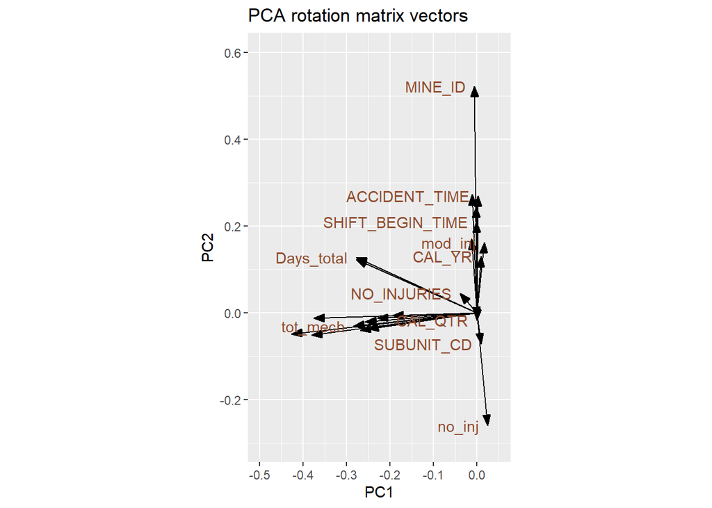

```r
# plot rotation matrix

pca_model %>%
  tidy(matrix = "rotation") %>%
  pivot_wider(
    names_from = "PC",
    names_prefix = "PC",
    values_from = "value") %>%
  ggplot(aes(PC1, PC2)) +
  geom_segment(
    xend = 0,
    yend = 0,
    arrow = arrow(
      angle = 20,
      ends = "first",
      type = "closed",
      length = grid::unit(8, "pt"))) +
  geom_text(
    aes(label = column),
    hjust = 1,
    nudge_x = -0.02,
    check_overlap = TRUE,
    color = "#904C2F") +
  xlim(-0.5, 0.05) +
  ylim(-.3, 0.6) +
  coord_fixed() +         # fix aspect ratio to 1:1
  labs(title = 'PCA rotation matrix vectors')
```

Okay, so again, doesn’t look spectacular, but at least it spreads out a little bit and has more than 2 directions visible to our human eyes.

Lastly, let’s just see how laughably low our variance explained is.

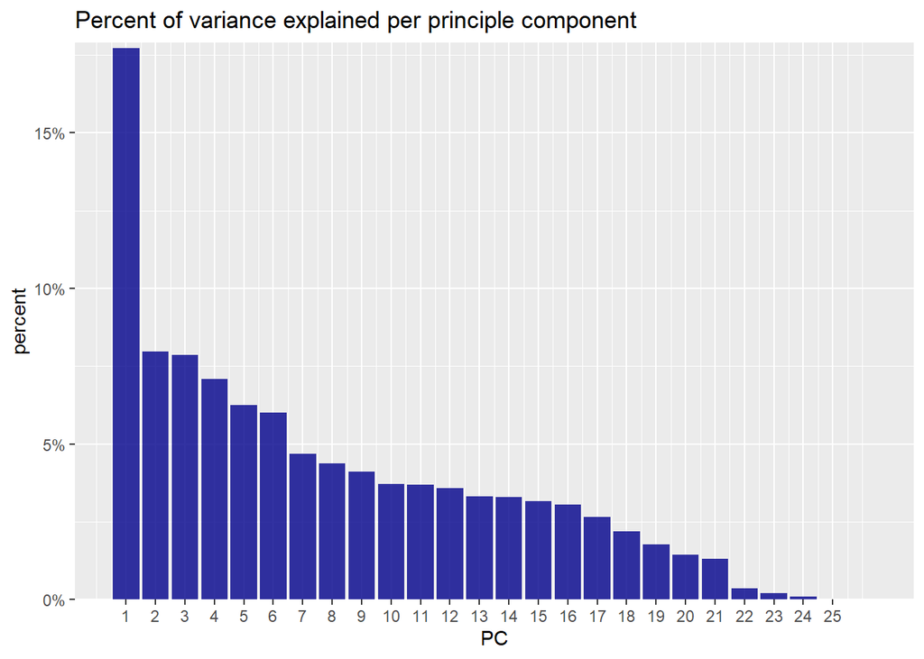

```r
pca_model %>%
  tidy(matrix = 'eigenvalues') %>%
  ggplot(
    aes(
      PC,
      percent)) +
  geom_col(
    fill = 'darkblue',
    alpha = 0.8) +
  scale_x_continuous(breaks = 1:25) +
  scale_y_continuous(
    labels = scales::percent_format(),
    expand = expansion(mult = c(0, 0.01))) +
  labs(title = 'Percent of variance explained per principle component')
```

As much as I’d love the total of the first 2 PCs to be closer to 50%, I’ll take ~25% for the time being. At least the first half dozen get us above 50%, so that’s not the end of the world.